# Assignment 1

Anna Lai

February 14, 2023

# Exploration of gene set associated with the Alzheimer’s disease

## Setup

Package installation commands hided.

```r
suppressPackageStartupMessages({
library(BiocManager)
library(GEOmetadb)
library(RSQLite)
library(readr)
library(utils)
library(base)
library(readxl)
library(biomaRt)
library(dplyr)
library(knitr)
library(AnnotationDbi)
library(org.Hs.eg.db)
library(wordcloud)
library(stringr)
library(edgeR)
})
```

## Data cleaning

### Information about the dataset

As the data description in GEO, there are 30 samples. Basic information about the dataset is shown below.

```r
metadata <- getGEO("GSE153873")

dim(metadata$GSE153873_series_matrix.txt.gz)
```

```
## Features  Samples
##        0       30
```

```r
metadata$GSE153873_series_matrix.txt.gz$contact_institute[1]
```

```
## [1] "University of Pennsylvania"
```

```r
metadata$GSE153873_series_matrix.txt.gz$contact_city[1]
```

```
## [1] "Philadelphia"
```

```r
metadata$GSE153873_series_matrix.txt.gz$contact_country[1]
```

```
## [1] "USA"
```

```r
metadata$GSE153873_series_matrix.txt.gz$status[1]
```

```
## [1] "Public on Jul 07 2020"
```

```r
metadata$GSE153873_series_matrix.txt.gz$submission_date[1]
```

```
## [1] "Jul 06 2020"
```

```r
metadata$GSE153873_series_matrix.txt.gz$last_update_date[1]
```

```
## [1] "Oct 13 2020"
```

```r
metadata$GSE153873_series_matrix.txt.gz$organism_ch1[1]
```

```
## [1] "Homo sapiens"
```

```r
metadata$GSE153873_series_matrix.txt.gz$source_name_ch1[1]
```

```
## [1] "Frozen postmortem brain tissue"
```

```r
metadata$GSE153873_series_matrix.txt.gz$`tissue:ch1`[1]
```

```
## [1] "Lateral temporal lobe"
```

```r
metadata$GSE153873_series_matrix.txt.gz$extract_protocol_ch1[1]
```

```
## [1] "RNA isolated from tissue was spiked with the ERCC Spike-In Mix (equal quantities) and subject to ribosomal RNA removal and sequencing library preparation."
```

### Information about the platform

```r
gse <- getGEO("GSE153873",GSEMatrix=FALSE)
current_gpl <- names(GPLList(gse))[1]
current_gpl_info <- Meta(getGEO(current_gpl))
current_gpl_info$`
title`
```

```
## [1] "Illumina NextSeq 500 (Homo sapiens)"
```

**Q1 What are the controls and the test conditions of the dataset?** There are 12 disease samples, 10 samples from old individuals, and 8 from young individuals.

**Q2 Why is this data set of interest to you?** Alzheimer’s disease (AD) has long thought to be an age related disease with an onset age at around 65 years old. By comparing the brain tissue samples of young, adult, and diseased brain, it can yield convincing results on certain genes that regulates the disease.

```r
exp_con <- data.frame(title = metadata$GSE153873_series_matrix.txt.gz$title,
           disease_state = metadata$GSE153873_series_matrix.txt.gz$`disease state:ch1`)
exp_con
```

| title | disease_state |
| --- | --- |
| 13-11T-Old | old |
| 15-13T-Old | old |
| 20-1T-AD | Alzheimer's disease |
| 16-14T-Old | old |
| 3-17T-Young | young |
| 5-18T-Young | young |
| 7-19T-Young | young |
| 21-1A-AD | Alzheimer's disease |
| 23-2A-AD | Alzheimer's disease |
| 26-3A-AD | Alzheimer's disease |

[output cut: 20 more lines]

```r
count <- table(exp_con$disease_state)
count
```

```
##
## Alzheimer's disease                 old               young
##                  12                  10                   8
```

### Extract data

```r
sfiles = getGEOSuppFiles('GSE153873')
fnames = rownames(sfiles)

new_fnames <- c()

for (string in fnames) {
  new_string <- sub(".*/Assignment1", "/Assignment1", string)
  new_fnames <- c(new_fnames, new_string)
}
new_fnames
```

```
## [1] "/Assignment1/GSE153873/GSE153873_AD.vs.Old_diff.genes.xlsx"
## [2] "/Assignment1/GSE153873/GSE153873_summary_count.ercc.txt.gz"
## [3] "/Assignment1/GSE153873/GSE153873_summary_count.star.txt.gz"
```

There are 3 supplementary files from this paper. In file 2 and 2, 31 columns are observed in each table, the first column is the Gene identifier.

```r
b1 = read_excel(fnames[1])
b2 = read.delim(fnames[2], header = TRUE)
b3 = read.delim(fnames[3], header = TRUE)

head(b1)
```

| ...1 | RO | RA | RA-RO | PRA-RO | Padj_PRA-RO |
| --- | --- | --- | --- | --- | --- |
| SGO1 | 0.889451 | 2.568363 | 1.6789117 | 2.233795e-09 | 2.393287e-05 |
| ANAPC16 | 6.289391 | 6.920068 | 0.6306775 | 1.183172e-08 | 4.051556e-05 |
| VTRNA2-1 | 3.692709 | 6.637819 | 2.9451106 | 1.323544e-08 | 4.051556e-05 |
| GNRH1 | 3.291807 | 4.685386 | 1.3935787 | 3.809156e-08 | 9.069177e-05 |
| RBM48 | 5.422133 | 6.162793 | 0.7406601 | 7.069546e-08 | 1.346774e-04 |
| KLF15 | 7.538113 | 8.746365 | 1.2082527 | 1.149435e-07 | 1.642007e-04 |

```r
head(b2)
```

|  | ERCCGene | X13.11T.Old | X15.13T.Old | X20.1T.AD | X16.14T.Old | X3.17T.Young | X5.18T.Young | X7.19T.Young | X21.1A.AD | X23.2A.AD | X26.3A.AD | X27.5A.AD | X12.6A.Old | X14.7A.Old | X10.8A.Old | X22.2T.AD | X17.9A.Old | X18.10A.Old | X19.11A.Old | X2.12A.Young | X4.13A.Young | X6.14A.Young | X8.15A.Young | X9.16A.Young | X24.3T.AD | X25.5T.AD | X29.6T.AD | X31.7T.AD | X28.8T.AD | … |
| --- | --- | --- | --- | --- | --- | --- | --- | --- | --- | --- | --- | --- | --- | --- | --- | --- | --- | --- | --- | --- | --- | --- | --- | --- | --- | --- | --- | --- | --- | --- |
| 1 | ERCC-00002 | 44892 | 36445 | 24990 | 22536 | 116124 | 103950 | 47969 | 32254 | 74487 | 68370 | 63052 | 67826 | 39215 | 41936 | 34467 | 27908 | 64427 | 51416 | 30878 | 29900 | 18625 | 141080 | 30069 | 58622 | 120249 | 74196 | 25732 | 116774 | … |
| 2 | ERCC-00003 | 1639 | 1009 | 530 | 478 | 1732 | 2673 | 1034 | 1379 | 3343 | 2166 | 2558 | 2397 | 1506 | 1742 | 1094 | 1137 | 2188 | 2205 | 1031 | 1232 | 873 | 4723 | 580 | 2269 | 2908 | 1968 | 654 | 2857 | … |
| 3 | ERCC-00004 | 2807 | 1350 | 547 | 590 | 2497 | 4453 | 1251 | 2593 | 6303 | 3383 | 4019 | 4136 | 2326 | 3176 | 1794 | 1620 | 3590 | 3938 | 1516 | 1938 | 1482 | 8885 | 661 | 3854 | 3938 | 2760 | 801 | 4683 | … |
| 4 | ERCC-00009 | 1658 | 1193 | 887 | 744 | 3335 | 3515 | 1650 | 1142 | 2511 | 2300 | 2352 | 2472 | 1551 | 1590 | 1235 | 957 | 2254 | 2015 | 1218 | 1172 | 744 | 4842 | 923 | 2090 | 3569 | 2410 | 1033 | 4062 | … |
| 5 | ERCC-00012 | 1 | 1 | 0 | 0 | 2 | 0 | 1 | 0 | 0 | 0 | 0 | 0 | 0 | 0 | 0 | 0 | 0 | 0 | 0 | 0 | 0 | 1 | 0 | 0 | 0 | 0 | 0 | 0 | … |
| 6 | ERCC-00013 | 1 | 1 | 1 | 1 | 9 | 3 | 5 | 2 | 4 | 5 | 3 | 1 | 1 | 2 | 1 | 0 | 2 | 0 | 2 | 3 | 2 | 6 | 0 | 4 | 2 | 2 | 0 | 8 | … |

```r
head(b3)
```

|  | refGene | X20.1T.AD | X13.11T.Old | X15.13T.Old | X16.14T.Old | X3.17T.Young | X5.18T.Young | X7.19T.Young | X21.1A.AD | X23.2A.AD | X26.3A.AD | X27.5A.AD | X22.2T.AD | X12.6A.Old | X14.7A.Old | X10.8A.Old | X17.9A.Old | X18.10A.Old | X19.11A.Old | X2.12A.Young | X4.13A.Young | X6.14A.Young | X8.15A.Young | X24.3T.AD | X9.16A.Young | X25.5T.AD | X29.6T.AD | X31.7T.AD | X28.8T.AD | … |
| --- | --- | --- | --- | --- | --- | --- | --- | --- | --- | --- | --- | --- | --- | --- | --- | --- | --- | --- | --- | --- | --- | --- | --- | --- | --- | --- | --- | --- | --- | --- |
| 1 | SGIP1 | 1405 | 1405 | 1169 | 2408 | 859 | 1164 | 1402 | 1441 | 1003 | 1265 | 987 | 1325 | 2238 | 1075 | 2756 | 2413 | 1748 | 1322 | 2602 | 3115 | 2953 | 1541 | 795 | 1614 | 833 | 1284 | 919 | 1004 | … |
| 2 | NECAP2 | 295 | 460 | 334 | 347 | 617 | 585 | 372 | 343 | 374 | 315 | 355 | 491 | 356 | 344 | 217 | 470 | 403 | 338 | 409 | 196 | 220 | 424 | 426 | 387 | 552 | 328 | 353 | 474 | … |
| 3 | AZIN2 | 356 | 306 | 385 | 507 | 787 | 751 | 577 | 238 | 209 | 241 | 211 | 440 | 421 | 296 | 427 | 394 | 360 | 264 | 611 | 323 | 396 | 394 | 179 | 424 | 567 | 292 | 301 | 319 | … |
| 4 | AGBL4 | 191 | 200 | 173 | 323 | 36 | 89 | 184 | 229 | 129 | 154 | 102 | 124 | 268 | 200 | 327 | 282 | 202 | 213 | 328 | 335 | 431 | 38 | 46 | 231 | 45 | 123 | 155 | 108 | … |
| 5 | CLIC4 | 876 | 1443 | 639 | 792 | 4806 | 5968 | 1392 | 1117 | 1247 | 929 | 1151 | 3674 | 1526 | 1269 | 719 | 4716 | 1361 | 819 | 2493 | 1332 | 729 | 8812 | 936 | 689 | 2534 | 856 | 646 | 1406 | … |
| 6 | SLC45A1 | 291 | 329 | 298 | 636 | 139 | 204 | 278 | 193 | 152 | 178 | 142 | 224 | 253 | 195 | 474 | 349 | 269 | 231 | 551 | 441 | 506 | 221 | 156 | 409 | 138 | 222 | 251 | 178 | … |

```r
dim(b1)
```

```
## [1] 421   6
```

```r
dim(b2)
```

```
## [1] 92 31
```

```r
dim(b3)
```

```
## [1] 27135    31
```

### Data and Sample condition

```r
b3_cols<- colnames(b3[2:31])
b3_cols_format <- c()
for (string in b3_cols) {
  new_string <- gsub("X(\\d+).(\\d+)(\\w+).(\\w+)", "\\1-\\2\\3-\\4", string)
  b3_cols_format <- c(b3_cols_format, new_string)
}
exp_con_merged <- merge(exp_con, data.frame(b3_cols = b3_cols, title = b3_cols_format), by = "title")
exp_con_merged
```

| title | disease_state | b3_cols |
| --- | --- | --- |
| 10-8A-Old | old | X10.8A.Old |
| 11-10T-Old | old | X11.10T.Old |
| 12-6A-Old | old | X12.6A.Old |
| 13-11T-Old | old | X13.11T.Old |
| 14-7A-Old | old | X14.7A.Old |
| 15-13T-Old | old | X15.13T.Old |
| 16-14T-Old | old | X16.14T.Old |
| 17-9A-Old | old | X17.9A.Old |
| 18-10A-Old | old | X18.10A.Old |
| 19-11A-Old | old | X19.11A.Old |

[output cut: 20 more lines]

### Gene Duplication

**Q Were there expression values that were not unique for specific genes?** It is likely that the expression values and the symbols have been cleaned before being deposited into the GEO. Hence, from tables before, there doesn’t seem to have expression values that were not unique.

**Q How did you handle replicates in this data?** There are no replicates in this data set.

```r
length(b3$refGene)-length(unique(b3$refGene))
```

```
## [1] 0
```

```r
# double checking there are no duplicated genes
summarized_gene_counts <- sort(table(b3$refGene),
decreasing = TRUE)
kable(table(b3$refGene)[1:5], format="html")
```

| Var1 | Freq |
| --- | --- |
| A1BG | 1 |
| A1BG-AS1 | 1 |
| A1CF | 1 |
| A2M | 1 |
| A2M-AS1 | 1 |

```r
kable(summarized_gene_counts[which(summarized_gene_counts>1)[1:5]],format="html")
```

| Var1 | Freq |
| --- | --- |
| NA | NA |
| NA | NA |
| NA | NA |
| NA | NA |
| NA | NA |

### HUGO symbol mapping

The data is already using HUGO symbol. Hence for the purpose of the assignment, I mapped them to ensembl_gene_id. From the code snippet below we conclude that there are 3592 genes without ensembl_gene_id, and 1466 genes maps to more than 1 ensembl_gene_id.

**Q Were there any expression values that could not be mapped to current HUGO symbols?** NO. The dataset uses HUGO notation.

```r
ensembl <- useMart("ensembl", dataset = "hsapiens_gene_ensembl")

genes_to_ensembl <- getBM(attributes = c("hgnc_symbol", "ensembl_gene_id"),
                           filters = "hgnc_symbol",
                           values = b3$refGene,
                           mart = ensembl)

# number of genes that are not mapped to Ensembl ID
included_in_both <- intersect(b3$refGene, genes_to_ensembl$hgnc_symbol)
length(b3$refGene)-length(included_in_both)
```

```
## [1] 3592
```

```r
# genes that mapped to more than 1 ensembl_gene_id
dup_rows <- duplicated(genes_to_ensembl$hgnc_symbol) | duplicated(genes_to_ensembl$hgnc_symbol, fromLast = TRUE)
duplicated_df <- genes_to_ensembl[dup_rows, ]
length(unique(duplicated_df$hgnc_symbol))
```

```
## [1] 1466
```

### Check and remove low count genes

```r
cpms = cpm(b3[, 2:dim(b3)[2]])
keep10 = rowSums(cpms >1) >=10
b3_filtered10 = b3[keep10,]

keep30 = rowSums(cpms >1) >=30
b3_filtered30 = b3[keep30,]

dim(b3)[1] - dim(b3_filtered10)[1]
```

```
## [1] 9713
```

```r
dim(b3)[1] - dim(b3_filtered30)[1]
```

```
## [1] 13149
```

```r
dim(b3_filtered10)[1] - dim(b3_filtered30)[1]
```

```
## [1] 3436
```

## Distribution of Data Before normalization

## GO term mapping

Mapping to the GO terms to observe the overall genes included in the data set after filtering out the low count genes.

```r
mapped_terms <- select(org.Hs.eg.db, keys=b3_filtered30$refGene, keytype="SYMBOL", columns= c("GENENAME", "ONTOLOGY" ,"PATH"))

freq_df <- data.frame(table(mapped_terms$PATH))

kegg_name <- rep("Not Found in KEGG", length(freq_df$Var1))

for (i in 1:length(freq_df$Var1)) {
  kegg_pathway <- paste("hsa", freq_df$Var1[i], sep = "")
  url <- paste("http://rest.kegg.jp/get/", kegg_pathway, sep = "")

    tryCatch(
    {
      lines <- readLines(url, warn = FALSE)
       match <- str_match(lines[2], "NAME\\s+(.*)\\s+-\\s+(.*)")
      if (!is.na(match[1,2])) {
        pathway_name <- match[1,2]
        organism_name <- match[1,3]
        kegg_name[i]<- pathway_name
      }
    },
    error = function(e) {
      message(paste0("ERROR: ", e$message))
    }
  )

}
# kegg_name
```

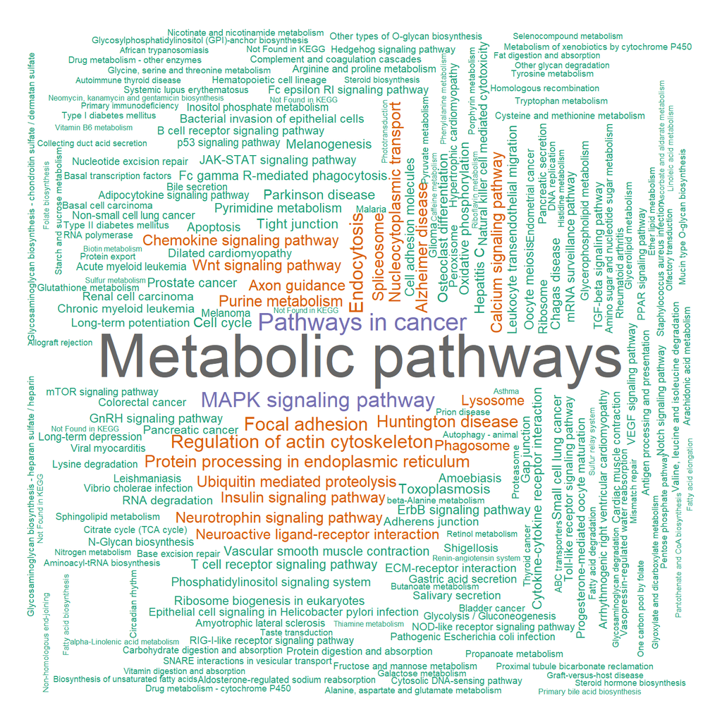

```r
wordcloud(words = kegg_name, freq = freq_df$Freq, min.freq = 1, max.words = 350, random.order = FALSE, rot.per = 0.35,
          colors = brewer.pal(28, "Dark2"))
```

### Box plot

At this stage, there is no clear separation between the overall expression data between the three sample groups: young, old, AD diseased. There are a lot of outliers in the data as shown in the box plot.

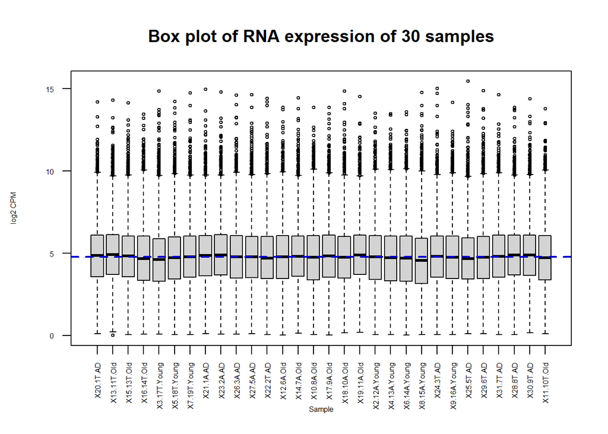

```r
b3plot <- log2(cpm(b3_filtered30[, 2:dim(b3_filtered30)[2]]))
boxplot(b3plot, xlab = "Sample", ylab = "log2 CPM",
las = 2, cex = 0.5, cex.lab = 0.5,
cex.axis = 0.5, main = "Box plot of RNA expression of 30 samples")

abline(h = median(apply(b3plot, 2, median)),
col = "blue3", lwd = 2, lty = "dashed")
```

### Density plot

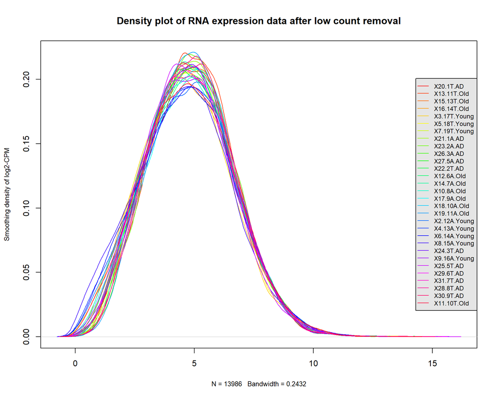

```r
plot_Density <- function(b3plot){
counts_density <- apply(b3plot, 2, density)

#calculate the limits across all the samples
xlim <- 0; ylim <- 0
for (i in 1:length(counts_density)) {
xlim <- range(c(xlim, counts_density[[i]]$x));
ylim <- range(c(ylim, counts_density[[i]]$y))
}
cols <- rainbow(length(counts_density))
ltys <- rep(1, length(counts_density))

#plot the first density plot to initialize the plot
plot(counts_density[[1]], xlim=xlim, ylim=ylim, type="n",
ylab="Smoothing density of log2-CPM", main="Density plot of RNA expression data after low count removal", cex.lab = 0.8)

#plot each line
for (i in 1:length(counts_density)) lines(counts_density[[i]], col=cols[i], lty=ltys[i])

#create legend
legend("right", colnames(b3plot),
col=cols, lty=ltys, cex=0.75,
border ="blue", text.col = "black",
merge = TRUE, bg = "gray90")
}

plot_Density(b3plot)
```